# Compare Timeseries of Network Stats Across Port Groups and to Other ESR Indicators

Preparation for network analysis in CCIEA ESR

M. Fisher, J.F. Samhouri

Written Dec 30, 2021. Last Run 2026-01-15

# Description

This document graphs network metrics over time for the US West Coast, and compares metrics across port groups and to other indicators in the ESR.

The core network metric of interest on its own is Edge Density (alt: Mean Degree).

The two core network metrics of interest for comparison to the Habitat Compression Index are:

1. Node Strength
2. Eigen Vector Centrality (aka Importance).

Initially, we consider the above 2 metrics for salmon and non-DTS groundfish for all ports.

Make sure to define filenames and networkstats_filename so that the date is associated with the most recent files

# Setup

This script requires the following packages.

```r
if(!require("tidyverse")) {install.packages("tidyverse")}
if(!require("foreign")) {install.packages("foreign")}
if(!require("lubridate")) {install.packages("lubridate")}
# if(!require("facetscales")) {devtools::install_github("zeehio/facetscales"); library(facetscales)} # this package was archived by the developer in 2022
if(!require("ggplot2")) {install.packages("ggplot2")}
if(!require("grid")) {install.packages("grid")}
if(!require("gridExtra")) {install.packages("gridExtra")}
if(!require("ggpubr")) {install.packages("ggpubr")}
if(!require("cowplot")) {install.packages("cowplot")}
if(!require("viridis")) {install.packages("viridis")}
if(!require("PNWColors")) {devtools::install_github("jakelawler/PNWColors"); library(PNWColors)}
```

Select your directories.

```r
## directory with network statistics
indir <- 'results/statistics'

## directory with other input data
other_indir <- 'data/input'

## directory to save figures
pngdir <- 'results/figures'
```

What are the names of the `.csv` files with the network statistics that you want to compare? Would not suggest listing more than 4. Files should all be in the input directory (`indir`) specified above.

```r
filenames <- "VesselLevelNodeStats_2004_2025_21pcgroups_totalrev7873.43337267464_indivrev787.343337267464_connectivity_rmCrab_10pContribution_2026-01-15.csv"
networkstats_filename <- c("VesselLevelNetworkStats_2004_2025_21pcgroups_totalrev7873.43337267464_indivrev787.343337267464_connectivity_rmCrab_10pContribution_2026-01-15.csv")
# hci_filename <- 'ei_hci_rgn1_M.csv'
port_filename <- 'iopac_conversion_table.csv'
```

Provide descriptive names to differentiate the datasets drawn from the files listed above.

```r
dataset_names <- c("Node_Stats")
dataset_names2 <- c("Network_Stats")
```

Specify which network metrics to retain from the full data set.

```r
node_metrics <- c('node_strength','eigen')
network_metrics <- c('ed', 'N') # ,'ed_weighted'
```

Specify which fisheries to retain from the full data set.

```r
myfisheries <- c('Salmon','Non-DTS groundfish', 'DTS groundfish')
```

# Read in Data

Network metrics from different datasets.

```r
for(i in seq(1,length(filenames))){
  tmpdat <- read.csv(here::here(indir, filenames[i])) %>%
    dplyr::select(pcgroup, year, metier.cm, all_of(node_metrics)) %>%
    #filter(pcgroup %in% myports) %>%
    filter(metier.cm %in% myfisheries) %>%
    mutate(dataset=dataset_names[i])
  if(i==1){
    dat <- tmpdat
  } else{ dat <- bind_rows(dat,tmpdat)}
}

glimpse(dat)
```

```
## Rows: 871
## Columns: 6
## $ pcgroup       <chr> "Puget Sound", "Puget Sound", "North WA Coast", "North W…
## $ year          <int> 2004, 2004, 2004, 2004, 2004, 2004, 2004, 2004, 2004, 20…
## $ metier.cm     <chr> "Salmon", "DTS groundfish", "Salmon", "DTS groundfish", …
## $ node_strength <dbl> 0.32430782, 0.24893179, 0.93048490, 1.00000000, 0.463632…
## $ eigen         <dbl> 7.781446e-01, 1.684919e-16, 9.972210e-01, 1.000000e+00, …
## $ dataset       <chr> "Node_Stats", "Node_Stats", "Node_Stats", "Node_Stats", …
```

```r
for(i in seq(1,length(networkstats_filename))){
  tmpdat2 <- read.csv(here::here(indir, networkstats_filename[i])) %>%
    dplyr::select(pcgroup, y, all_of(network_metrics)) %>%
    #filter(pcgroup %in% myports) %>%
    #filter(metier.cm %in% myfisheries) %>%
    mutate(dataset=dataset_names2[i])
  if(i==1){
    dat2 <- tmpdat2
  } else{ dat2 <- bind_rows(dat2,tmpdat2)}
}

glimpse(dat2)
```

```
## Rows: 448
## Columns: 5
## $ pcgroup <chr> "Puget Sound", "North WA Coast", "WA Coast", "Other Coastal Wa…
## $ y       <int> 2004, 2004, 2004, 2004, 2004, 2004, 2004, 2004, 2004, 2004, 20…
## $ ed      <dbl> 0.2000000, 0.1333333, 0.5277778, NA, 0.6666667, 0.3928571, 1.0…
## $ N       <int> 10, 6, 9, 1, 9, 8, 2, 6, 7, 7, 6, 8, 8, 6, 8, 10, 11, 9, 11, 1…
## $ dataset <chr> "Network_Stats", "Network_Stats", "Network_Stats", "Network_St…
```

```r
# 01-06-22: note jameal updated OSD, SD, and SDA ports to have the same lat long as OCN. Amanda P has made the same fix. Also reassigned MCR to the Eureka IOPAC port group,  Amanda P agreed with this change
iopac_lookup <- read_csv(here::here(other_indir, port_filename))
```

Check to make sure that all of the datasets were read in.

```
##             pcgroup
## dataset      Astoria Bodega Bay Brookings Columbia River Coos Bay Crescent City
##   Node_Stats      56         45        54             22       47            32
##             pcgroup
## dataset      Eureka Fort Bragg Los Angeles Monterey Morro Bay Newport
##   Node_Stats     45         60          34       60        57      43
##             pcgroup
## dataset      North WA Coast Other Coastal Washington Puget Sound San Diego
##   Node_Stats             45                        5          47        29
##             pcgroup
## dataset      San Francisco Santa Barbara Tillamook Unknown Ports WA Coast
##   Node_Stats            50            34        51            14       41
```

Pivot longer to graph multiple metrics at once.

```r
dat_long <- dat %>%
  pivot_longer(cols=c(all_of(node_metrics)), names_to = "metric", values_to = "value")

dat2_long <- dat2 %>%
  pivot_longer(cols=c(all_of(network_metrics)), names_to = "metric", values_to = "value")
```

Clean up metric names.

```r
dat_long$metric <- recode(dat_long$metric,
                          node_strength = "Node Strength",
                          eigen = "Importance")
#dat_long$metric <- factor(dat_long$metric, levels=c("Size", "Edge Density","Mean Degree", "Central.", "Central. (UnW)", "Mod.", "Mod. (UnW)"))

#dat_long$pcgroup <- factor(dat_long$pcgroup, levels=myports)

colnames(dat2) <- c(
  'Port Group','Year','Edge Density','N','dataset'
)

dat2_long$metric <- recode(dat2_long$metric,
                          'ed' = 'edge density',
                          'N' = 'number of fisheries')
```

convert to ESR format (Drop Other Coastal Washington & Unknown Ports & Columbia River)

```r
# format for ESR with the following columns:
# (1) year - this can be just year or a date, preferably in yyyy or yyyy-mm-dd format.
# (2) index - this column contains the data you want to plot
# (3) timeseries - title for the time series plot.
# (4) metric - how the data were measured; essentially the label for the y-axis
# (5) SE or SD if you have it
#
# NAs or blanks will not be plotted
# Zeros will be plotted
# You don't have to fill in missing years

# note that for each year, it reflects november of (year) through november of (year + 1). specifically week 46 of year 1 through week 45 of year 2

dat_esr1 <- dat_long %>%
  mutate(metric = paste(metier.cm, metric)) %>%
  dplyr:: select(year, value, metric, pcgroup) %>%
  rename(
    index = value,
    timeseries = pcgroup
  )

dat_esr2 <- dat2_long %>%
  dplyr:: select(y, value, metric, pcgroup) %>%
  rename(
    year = y,
    index = value,
    timeseries = pcgroup
  )


# Bind and (Drop Other Coastal Washington & Unknown Ports & Columbia River)
dat_esr <- dat_esr1 %>% bind_rows(dat_esr2) %>%
  filter( timeseries != "Other Coastal Washington" & timeseries != "Unknown Ports" & timeseries != "Columbia River")

write.csv(dat_esr,here::here(indir, paste0('FPN_ed_n_ns_ec_salmon_nondts_dts_FY2026.csv',"_",Sys.Date())), row.names=FALSE)
```

# 2. Graph Timeseries

## Figure x.Time series of node strength

```
## `geom_line()`: Each group consists of only one observation.
## ℹ Do you need to adjust the group aesthetic?
## `geom_line()`: Each group consists of only one observation.
## ℹ Do you need to adjust the group aesthetic?
```

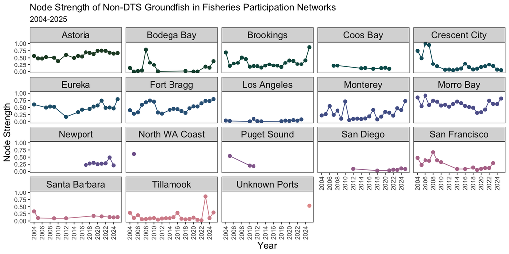

```
## `geom_line()`: Each group consists of only one observation.
## ℹ Do you need to adjust the group aesthetic?
```

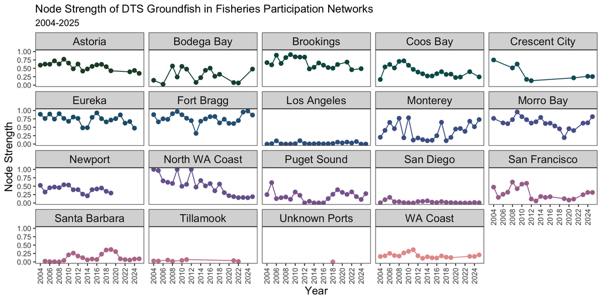

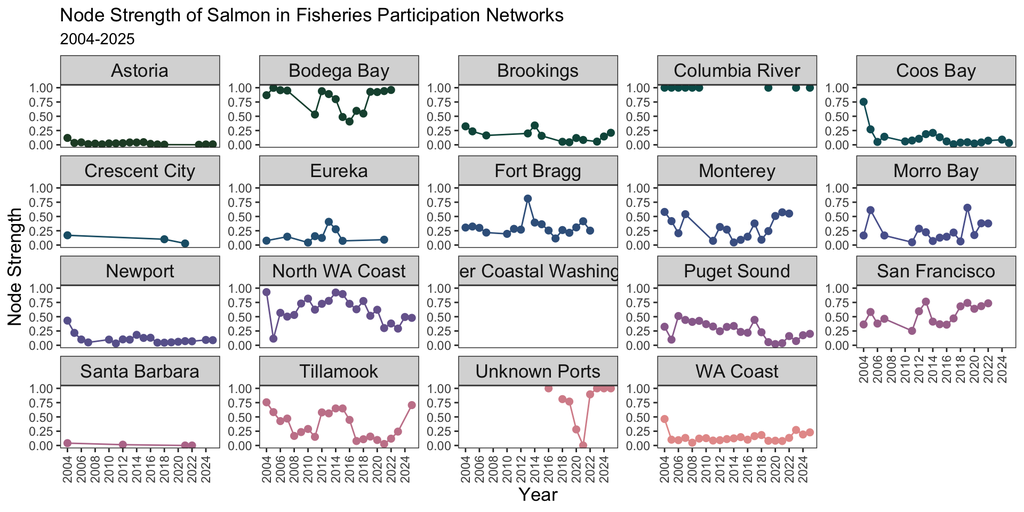

```r
plot_metric="Node Strength"
metric_label="Node Strength"
```

Save plot as a png, with filename: Node Strength of Non-DTS Groundfish in Fisheries Participation Networks 2004-2025

```
## `geom_line()`: Each group consists of only one observation.
## ℹ Do you need to adjust the group aesthetic?
## `geom_line()`: Each group consists of only one observation.
## ℹ Do you need to adjust the group aesthetic?
```

Save plot as a png, with filename: Node Strength of DTS Groundfish in Fisheries Participation Networks 2004-2025

```
## `geom_line()`: Each group consists of only one observation.
## ℹ Do you need to adjust the group aesthetic?
```

## Figure y.Time series of importance

```
## `geom_line()`: Each group consists of only one observation.
## ℹ Do you need to adjust the group aesthetic?
## `geom_line()`: Each group consists of only one observation.
## ℹ Do you need to adjust the group aesthetic?
```

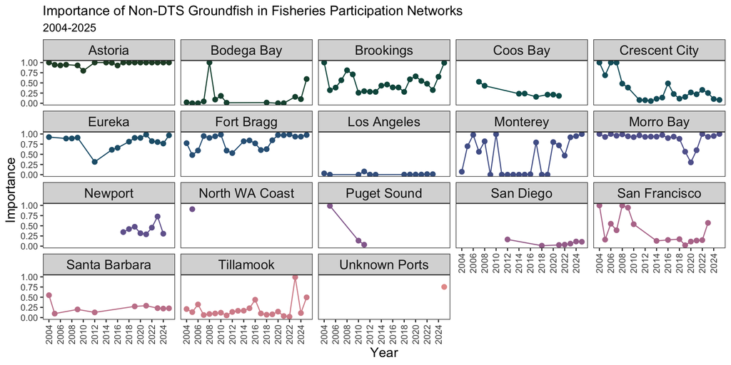

```
## `geom_line()`: Each group consists of only one observation.
## ℹ Do you need to adjust the group aesthetic?
```

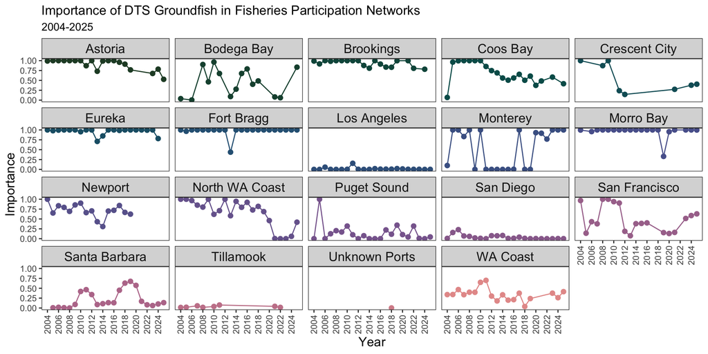

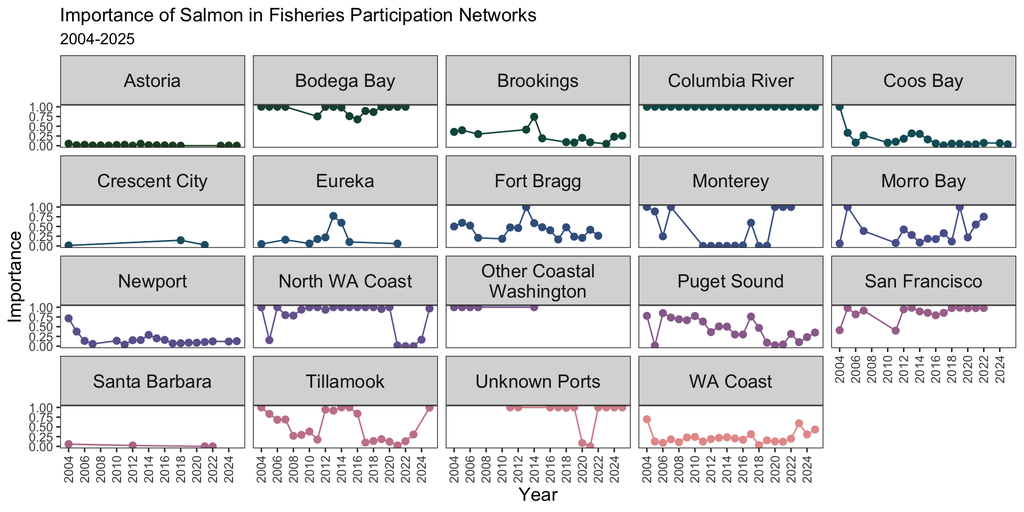

```r
plot_metric="Importance"
metric_label="Importance"
```

Save plot as a png, with filename: Importance of Non-DTS Groundfish in Fisheries Participation Networks 2004-2025

```
## `geom_line()`: Each group consists of only one observation.
## ℹ Do you need to adjust the group aesthetic?
## `geom_line()`: Each group consists of only one observation.
## ℹ Do you need to adjust the group aesthetic?
```

Save plot as a png, with filename: Importance of DTS Groundfish in Fisheries Participation Networks 2004-2025

```
## `geom_line()`: Each group consists of only one observation.
## ℹ Do you need to adjust the group aesthetic?
```

Save plot as a png, with filename: Importance of Salmon in Fisheries Participation Networks 2004-2025

## Figure aa. Time series of edge density

… at all ports from 2005-2025. Edge density was derived from vessel-level networks summarized at the port level. Nodes (fisheries) are included in each network with a minimum total fisheries revenue cutoff for vessels of `$5,000` (USD in 2005; following Holland et al. diversification indices) and a minimum revenue cutoff for individual fisheries of `$500` (USD in 2005; following Holland et al. diversification indices).

(Drop Other Coastal Washington & Unknown Ports & Columbia River)

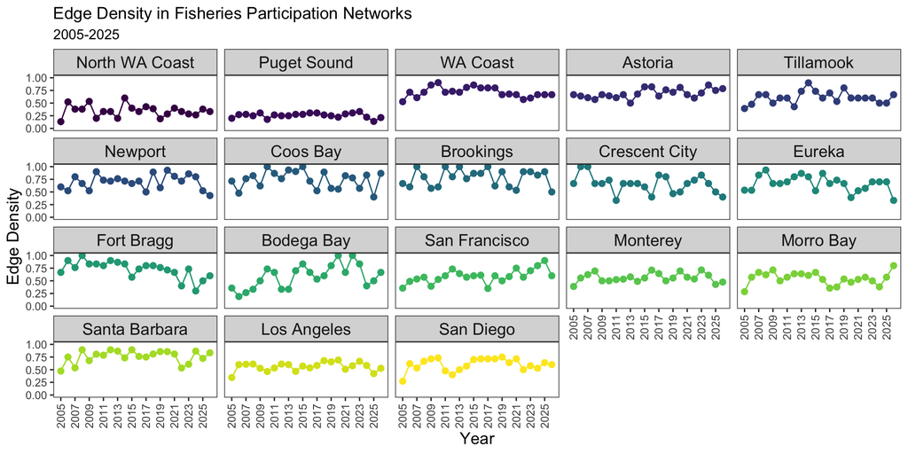

```r
plot_metric="Edge Density"
metric_label="Edge Density"
```

## Figure bb. Time series of number of nodes

… at all ports from 2004-2025. The number of nodes was derived from vessel-level networks summarized at the port level. Nodes (fisheries) are included in each network with a minimum total fisheries revenue cutoff for vessels of `$5,000` (USD in 2005; following Holland et al. diversification indices) and a minimum revenue cutoff for individual fisheries of `$500` (USD in 2005; following Holland et al. diversification indices). To avoid inclusion of rare or minimal fishing activity, a given fishery must contribute to at least 10% of a vessel’s annual revenue to be included in the network data.

(Drop Other Coastal Washington & Unknown Ports & Columbia River)

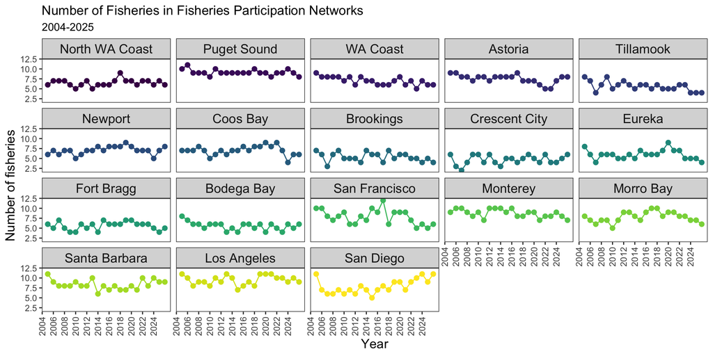

```r
plot_metric="N"
metric_label="Number of fisheries"
```